Radha Venkatesan  
STAT 395  
Final Project  
December 5, 2017

# Who Let the Dogs Out? (ft. Dogs of NYC)

You’ve heard of Humans of NY….now get ready to have your mind blown by….the Dogs of NY(C)!!!!

## Project Goals/ Objective

The goal of this project is to predict the breed of the dog based on its name, characteristics and where it is from, all specifically for New York City (NYC).

One possible use of the model is to identify lost dogs in NYC. If you know the name and/or characteristics of the dog, you can predict the breed of dog you are trying to identify.

Another possible use is for dog owners to predict what breed a dog probably is if they meet a dog in the dog parks of NYC or if they are adopting a dog from NYC.

## Set-up

Read in the following libraries and to load the metadata:

```r
library(readr)
library(dplyr)
```

```r
library(ggplot2)
library(viridis)
library(ggmap)

rawData <- read_csv("Dogs of NYC _ WNYC.csv")
```

## Data Pre-Processing

In total, the data set contains 81,542 entries.

The data contains, for each dog: - dog name - gender - breed - birth day - dominant color - secondary color - third color - spayed or neutered (character value) - guard or trained (character value) - which part of NY a.k.a borough - zipcode

*Creating the training and validation sets:*

The data set is split into a training set and a validation set. About 70% of the data is assigned to the training set and 30% is assigned to the validation set.

The data set with the assigned train and valid labels for each data is stored into the file dogsNYC.

```r
dogsNYC <- rawData
dogsNYC$train_id <- sample( c("train", "valid"), nrow(dogsNYC), replace = TRUE, prob = c(0.7, 0.3))
```

*Assigning breed name of dog to a numerical value:*

The table below displays the breed names and the number of dogs classified under each breed.

In total there are 138 different breeds of dogs in NYC. Therefore, these breeds have to be assigned to classes 1 - 138, where 1 is the first breed of dog, the Afghan Hound, and 138 is the last breed of dog, the Yorkshire Terrier.

Fun fact: The AKC recognizes 190 different breeds of dogs (AKC).

```r
table(dogsNYC$breed)
```

```
##
##                         Afghan Hound                                Akita
##                                   15                                  125
##                     Akita Crossbreed                  American Eskimo dog
##                                   37                                  215
## American Pit Bull Mix / Pit Bull Mix   American Pit Bull Terrier/Pit Bull
##                                  829                                 1662
##       American Staffordshire Terrier                 Australian Cattledog
##                                  464                                   91
##                    Australian Kelpie                  Australian Shepherd
##                                    6                                  239
##             Australian Silky Terrier                              Basenji
##                                   19                                   96
##                        Bassett Hound                               Beagle
##                                  178                                 1475
##                    Beagle Crossbreed                   Bedlington Terrier
##                                  419                                    6
##                      Belgian Griffon                     Belgian Malinois
##                                   10                                   36
##                     Belgian Sheepdog                 Bernese Mountain Dog
##                                   18                                   84
##                         Bichon Frise                           Bloodhound
##                                 1017                                   14
##                       Border Terrier                               Borzoi
##                                  120                                    6
##                       Boston Terrier                 Bouvier Des Flandres
##                                  860                                   10
##                                Boxer                               Briard
##                                  848                                   16
##                     Brittany Spaniel                     Brussels Griffon
##                                   61                                  198
##                    Bull Dog, English                     Bull Dog, French
##                                  688                                  872
##                         Bull Terrier                        Cairn Terrier
##                                  144                                  367
##                           Cane Corso        Cavalier King Charles Spaniel
##                                  143                                  744
##             Chesapeake Bay Retriever                            Chihuahua
##                                   10                                 3604
##                            Chow Chow                      Clumber Spaniel
```

[output cut: 84 more lines]

```
##                                 4765                                  587
##                        Silky Terrier                         Skye Terrier
##                                  288                                    7
##           Staffordshire Bull Terrier                      Tibetan Spaniel
##                                  137                                   39
##                      Tibetan Terrier                               Vizsla
##                                  154                                  119
##                           Weimaraner                Welsh Corgi, Cardigan
##                                  134                                   34
##                Welsh Corgi, Pembroke              West High White Terrier
##                                  148                                  479
##                      Wheaton Terrier                              Whippet
##                                  312                                   75
##                     Wire Fox Terrier                    Yorkshire Terrier
##                                   82                                 4915
```

The code below assigns each breed of dog to a numerical value (as described above), from 1 to the max number of classes, which here is 138.

```r
dogsNYC$class <- as.integer(factor(dogsNYC$breed))
```

In order to run certain models, some of the other non-numerical values have to be converted to numerical classes.

The same process as above in assigning dog breeds to classes is used on the remaining non-numerical values.

```r
# Assigning numerical value for name
dogsNYC$name_class<- as.integer(factor(dogsNYC$dog_name))

# Assigning numerical value for gender
dogsNYC$gender_class<- as.integer(factor(dogsNYC$gender))

# Assigning numerical value for dominant color
dogsNYC$dcolor_class<- as.integer(factor(dogsNYC$dominant_color))

# Assigning numerical value for secondary color
dogsNYC$scolor_class<- as.integer(factor(dogsNYC$secondary_color))

# Assigning numerical value for tertiary color
dogsNYC$tcolor_class<- as.integer(factor(dogsNYC$third_color))

# Assigning numerical value for spayed or neutered (binary values)
dogsNYC$spayNeuter_class<- as.integer(factor(dogsNYC$spayed_or_neutered))

# Assigning numerical value for guard or trained (binary values)
dogsNYC$guardTrained_class<- as.integer(factor(dogsNYC$guard_or_trained))

# Assigning numerical value for borough
dogsNYC$borough_class<- as.integer(factor(dogsNYC$borough))
```

## Predicting Breed of Dog

To get a sense of how well a model is doing, if using a random guessing model, the chance of prediciting the correct breed based on given characteristics would be 0.0072.

Therefore, the goal is to get a classification rate better than 0.0072 for the training and validation sets.

## ———————————————————————————————————————–

Stranger, Bernese Mountain Dog (8 y/o), Prospect Park, Brooklyn, NY • “He’s everybody’s friend and has a very impressive Rolodex. He’s Jon Stewart’s favorite dog as proclaimed by him on television.” (Source: The Dogist)

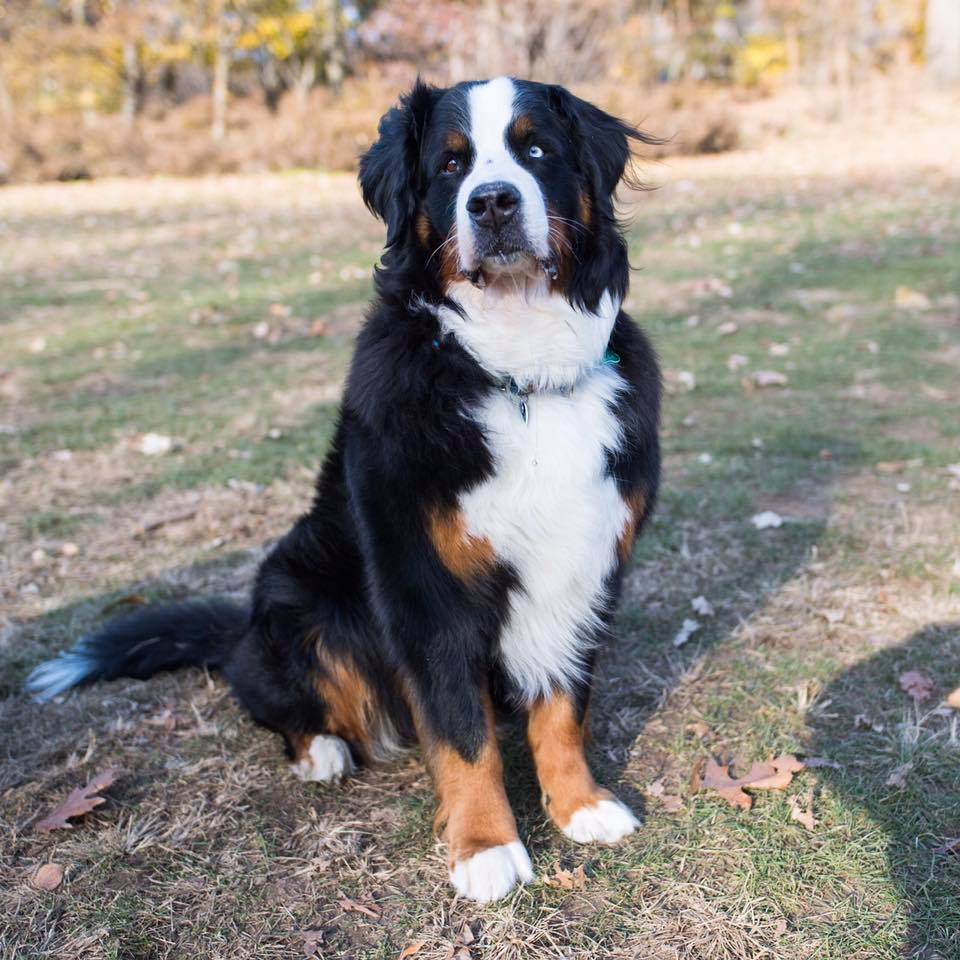

## ———————————————————————————————————————–

## K-nearest Neighbors Using the FNN Library

The first model created makes use of the k-nearest neighbors method. The library used is FNN (fastest nearest neighbors).

```r
library(nnet)
library(FNN)
```

The model matrix is created in order to use the data with FNN.

The factors selected for the model include all the three levels of colors and the borough of NYC from which a dog is from. It makes sense to select these factors to identify a breed of dog. Most breeds of dogs have a limited range in coloring and the borough of NYC they come from can also help identify them as some dogs are suitable for apartment vs. single-family/town-house housing complexes.

```r
X <- as.matrix(select(dogsNYC, dcolor_class, scolor_class, tcolor_class, borough_class))
y <- dogsNYC$class

X_train <- X[dogsNYC$train_id == "train",]
y_train <- y[dogsNYC$train_id == "train"]
```

The k parameter inside the knn function is set to 300.

```r
dogsNYC$breed_pred <- knn(train = X_train, test = X,
                     cl = y_train, k = 300)
```

```r
tapply(dogsNYC$breed_pred == dogsNYC$class, dogsNYC$train_id, mean)
```

```
##     train     valid
## 0.3164608 0.3138513
```

The training classification rate is about 0.32 and the validation classification rate is about 0.31; therefore about 31% of the guesses made about the prediction is correct. This is much better than random guessing and there is no apparent overfitting in the model. So, this is a good model for predicting the breed of the dog based on given characteristics.

But can we do better?

What if we include the gender of the dog, if it is guard or trained and take out the third coloring? (Note: Everything else in the model is kept the same from before.)

```r
X <- as.matrix(select(dogsNYC, guardTrained_class, gender_class, borough_class, dcolor_class, scolor_class))
y <- dogsNYC$class

X_train <- X[dogsNYC$train_id == "train",]
y_train <- y[dogsNYC$train_id == "train"]
```

```r
dogsNYC$breed_pred1 <- knn(train = X_train, test = X,
                     cl = y_train, k = 300)
```

```r
tapply(dogsNYC$breed_pred1 == dogsNYC$class, dogsNYC$train_id, mean)
```

```
##     train     valid
## 0.3170740 0.3182245
```

This model gives only slightly better results and is just as good as the previous knn model. There is no apparent overfitting present and this is still a better model than random guessing.

What about if all we know is just the name of the dog? (Note: Everything else in the model is kept the same from before.)

```r
X <- as.matrix(select(dogsNYC, name_class))
y <- dogsNYC$class

X_train <- X[dogsNYC$train_id == "train",]
y_train <- y[dogsNYC$train_id == "train"]
```

```r
dogsNYC$breed_pred2 <- knn(train = X_train, test = X,
                     cl = y_train, k = 300)
```

```r
tapply(dogsNYC$breed_pred2 == dogsNYC$class, dogsNYC$train_id, mean)
```

```
##     train     valid
## 0.2836093 0.2869171
```

What about if we know the name of the dog, where from NYC it is from and its first and secondary colorings? (Note: Everything else in the model is kept the same from before.)

```r
X <- as.matrix(select(dogsNYC, name_class, borough_class, dcolor_class, scolor_class))
y <- dogsNYC$class

X_train <- X[dogsNYC$train_id == "train",]
y_train <- y[dogsNYC$train_id == "train"]
```

```r
dogsNYC$breed_pred2 <- knn(train = X_train, test = X,
                     cl = y_train, k = 300)
```

```r
tapply(dogsNYC$breed_pred2 == dogsNYC$class, dogsNYC$train_id, mean)
```

```
##     train     valid
## 0.2841700 0.2874075
```

What about other kinds of models? Will those give us better predictions?

## ———————————————————————————————————————–

Teddy, Norwich Terrier (7 y/o), Astor Place, New York, NY • “He’s the mayor of Union Square. He rules the dog park.” (Source: The Dogist)

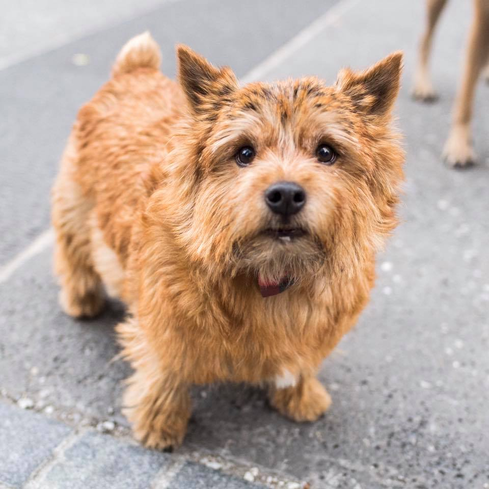

## ———————————————————————————————————————–

## Keras (Classification with Neural Networks)

The second model created makes use of the keras method. The library used is keras for classification with neural networks.

```r
X <- as.matrix(select(dogsNYC, dcolor_class, scolor_class, tcolor_class, borough_class))
```

```r
library(keras)
```

The y variable is created as before except the classes is subtracted by 1 so that the smallest category is 0.

The to_categorical function is used when creating the y_train and the y_valid so that there are no errors when creating the model using keras.

The number of classes is set to 138.

```r
X_train <- X[dogsNYC$train_id == "train",]
X_valid <- X[dogsNYC$train_id == "valid",]

y <- dogsNYC$class - 1
y_train <- to_categorical(y[dogsNYC$train_id == "train"], num_classes = 138)
y_valid <- to_categorical(y[dogsNYC$train_id == "valid"], num_classes = 138)
```

The input shape for the model is 4 since we have four input variables: dcolor_class, scolor_class, tcolor_class, borough_class.

Four layers are used with the fifth layer having 138 units since this corresponds to the number of classes there are.

```r
model <- keras_model_sequential()
model %>%
  layer_dense(units = 20, input_shape = c(4)) %>%
  layer_activation(activation = "relu") %>%
  layer_dense(units = 20) %>%
  layer_activation(activation = "relu") %>%
  layer_dense(units = 20) %>%
  layer_activation(activation = "relu") %>%
  layer_dense(units = 20) %>%
  layer_activation(activation = "relu") %>%
  layer_dense(units = 138) %>%
  layer_activation(activation = "softmax")
model
```

```
## Model
## ___________________________________________________________________________
## Layer (type)                     Output Shape                  Param #
## ===========================================================================
## dense_1 (Dense)                  (None, 20)                    100
## ___________________________________________________________________________
## activation_1 (Activation)        (None, 20)                    0
## ___________________________________________________________________________
## dense_2 (Dense)                  (None, 20)                    420
## ___________________________________________________________________________
## activation_2 (Activation)        (None, 20)                    0
## ___________________________________________________________________________
## dense_3 (Dense)                  (None, 20)                    420
## ___________________________________________________________________________
## activation_3 (Activation)        (None, 20)                    0
## ___________________________________________________________________________
## dense_4 (Dense)                  (None, 20)                    420
## ___________________________________________________________________________
## activation_4 (Activation)        (None, 20)                    0
## ___________________________________________________________________________
## dense_5 (Dense)                  (None, 138)                   2898
## ___________________________________________________________________________
## activation_5 (Activation)        (None, 138)                   0
## ===========================================================================
## Total params: 4,258
## Trainable params: 4,258
## Non-trainable params: 0
## ___________________________________________________________________________
```

The model has a little over 4,250 parameters to learn.

The model is then compiled using “categorical_crossentropy” for doing multiclass classification. The total number of epochs is set to 50.

```r
model %>% compile(loss = 'categorical_crossentropy',
                  optimizer = optimizer_rmsprop(lr = 0.01),
                  metrics = c('accuracy'))
model %>%
  fit(X_train, y_train, epochs = 50,
      validation_data = list(X_valid, y_valid))
```

The predict_classes function is used to get predictions on the whole dogsNYC dataset.

In order to get the correct predictions, a 1 is added back to the prediction.

```r
dogsNYC$breed_pred3 <- predict_classes(model, x = X) + 1

tapply(dogsNYC$breed_pred3 == dogsNYC$class, dogsNYC$train_id, mean)
```

```
##     train     valid
## 0.2833990 0.2865084
```

Can we use any other model to get better results?

## ———————————————————————————————————————–

## Gradient Boosted Trees (GBT) for Multinomial Classification

The third model created is the GBT for multinom. classification.

First, a model matrix is constructed. The values for the model matrix are the same as the ones used for the first model using knn. The value 1 is subtracted from the classes so the classes range from 0 - 137.

```r
X <- model.matrix(~ dcolor_class + scolor_class + tcolor_class + borough_class, data = dogsNYC)

y <- dogsNYC$class - 1

X_train <- X[dogsNYC$train_id == "train",]
X_valid <- X[dogsNYC$train_id == "valid",]
y_train <- y[dogsNYC$train_id == "train"]
y_valid <- y[dogsNYC$train_id == "valid"]
```

For the GBT model, the objective is set to “multi:softmax” with the num_class paramter set to 138. This specification is needed in order to correctly model a multinomial classification model that predicts the actual class versus class probabilities.

The nrounds is set to 10.

```r
library(xgboost)
data_train <- xgb.DMatrix(data = X_train, label = y_train)
data_valid <- xgb.DMatrix(data = X_valid, label = y_valid)

watchlist <- list(train=data_train, valid=data_valid)

model <- xgb.train(data = data_train,
                 max_depth = 4, eta = 0.7, nthread = 2,
                 nrounds = 10, objective = "multi:softmax", num_class = 138,
                 watchlist = watchlist)
```

The value 1 is added back again to the model predictions.

```r
dogsNYC$breed_predGBT <- predict(model, newdata = X) + 1

tapply(dogsNYC$breed_predGBT == dogsNYC$class, dogsNYC$train_id, mean)
```

```
##      train      valid
## 0.01752081 0.01761556
```

## ———————————————————————————————————————–

## Concluding Thoughts

From the results, it seems that creating a model based on k-nearest neighbors is best when it comes to predicting the breed of the dog based on given charactersitics, such as its coloring and where from NYC the pupper is from.

If using GBT model, using very large values for nrounds may help. Additionally, tuning the eta to different values could also make the GBT model perform better.

## ———————————————————————————————————————–

Frankie, French Bulldog (1 y/o), 46th & 11th Ave., New York, NY • “When she’s not watched she does anything she wants and terrorizes the apartment. She’s perfect when she’s being watched.” (Source: The Dogist)

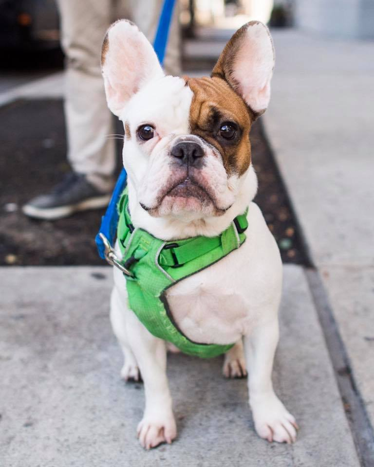

## ———————————————————————————————————————–

## References

Dogs of NYC - Database for Project: - https://fusiontables.google.com/data?docid=1pKcxc8kzJbBVzLu_kgzoAMzqYhZyUhtScXjB0BQ#rows:id=1 - https://www.kaggle.com/new-york-city/nyc-dog-names

Modeling - Code Base: - https://statsmaths.github.io/stat395/class08/ - https://statsmaths.github.io/stat395/class11/

AKC. “Breeds by Year Recognized.” American Kennel Club (AKC), 02 Dec. 2017, http://www.akc.org/press-center/facts-stats/page-3/.

The Dogist. https://www.facebook.com/thedogist/.